# Two Sigma Connect: Rental Listing Inquiries - EDA

Lateral Analytics

# Exploratory Data Analysis of Renthop data.

This is the initial exploratory section of the project. It also creates some simple features.

## Remove all objects

```r
rm(list = ls())
```

## Load libraries

```r
# Clear any previously loaded packages
pkgs_1 = names(sessionInfo()$otherPkgs)
pkgs_2 = paste('package:', pkgs_1, sep = "")
if (length(pkgs_1) > 0){
  lapply(pkgs_2, detach, character.only = TRUE, unload = TRUE)
}

library("tidyverse")
library("rjson")
library("rmarkdown")
library("lubridate")
```

```r
library("ggplot2")
library("maps")
library("mapproj")
library("RColorBrewer")
library("wordcloud")
```

## Load data

Save as an RDS file, so that we don’t need to constantly reload this data for other scripts.

```r
data_train <- rjson::fromJSON(file= "../data/train.json" )
data_test <- rjson::fromJSON(file= "../data/test.json" )

# unlist every variable except `photos` and `features` and convert to tibble
vars_train <- setdiff(names(data_train), c("photos", "features"))
vars_test <- setdiff(names(data_test), c("photos","features"))

data_train <- map_at(data_train, vars_train, unlist) %>% tibble::as_tibble(.) %>%
  mutate(section = 'train')

data_test <- map_at(data_test, vars_test, unlist) %>% tibble::as_tibble(.) %>%
  mutate(interest_level = 'none',
         section = 'test')

data <- rbind(data_train,data_test)

saveRDS(data, file = "../data/objects/data.rds")
```

## View the data.

```r
data[1:3,]
```

```
## # A tibble: 3 × 16
##   bathrooms bedrooms                      building_id             created
##       <dbl>    <dbl>                            <chr>               <chr>
## 1         1        1 8579a0b0d54db803821a35a4a615e97a 2016-06-16 05:55:27
## 2         1        2 b8e75fc949a6cd8225b455648a951712 2016-06-01 05:44:33
## 3         1        2 cd759a988b8f23924b5a2058d5ab2b49 2016-06-14 15:19:59
## # ... with 12 more variables: description <chr>, display_address <chr>,
## #   features <list>, latitude <dbl>, listing_id <dbl>, longitude <dbl>,
## #   manager_id <chr>, photos <list>, price <dbl>, street_address <chr>,
## #   interest_level <chr>, section <chr>
```

There are more than one features or photos for most of the listings.

## Check for missing values

```r
## There aren't any missing values in both train and test.

print(data_na <- data %>% summarise_each(funs(sum(is.na(.)))))
```

```
## # A tibble: 1 × 16
##   bathrooms bedrooms building_id created description display_address
##       <int>    <int>       <int>   <int>       <int>           <int>
## 1         0        0           0       0           0               0
## # ... with 10 more variables: features <int>, latitude <int>,
## #   listing_id <int>, longitude <int>, manager_id <int>, photos <int>,
## #   price <int>, street_address <int>, interest_level <int>, section <int>
```

## Exploration / Simple Features

### Check Header

```r
listings <- data %>%
  select(-features, - photos)
head(listings)
```

```
## # A tibble: 6 × 14
##   bathrooms bedrooms                      building_id             created
##       <dbl>    <dbl>                            <chr>               <chr>
## 1       1.0        1 8579a0b0d54db803821a35a4a615e97a 2016-06-16 05:55:27
## 2       1.0        2 b8e75fc949a6cd8225b455648a951712 2016-06-01 05:44:33
## 3       1.0        2 cd759a988b8f23924b5a2058d5ab2b49 2016-06-14 15:19:59
## 4       1.5        3 53a5b119ba8f7b61d4e010512e0dfc85 2016-06-24 07:54:24
## 5       1.0        0 bfb9405149bfff42a92980b594c28234 2016-06-28 03:50:23
## 6       1.0        3 300d27d8ba2adbcbc8c6f2bcbc1c6f9d 2016-06-28 05:59:06
## # ... with 10 more variables: description <chr>, display_address <chr>,
## #   latitude <dbl>, listing_id <dbl>, longitude <dbl>, manager_id <chr>,
## #   price <dbl>, street_address <chr>, interest_level <chr>, section <chr>
```

### Check count of listings in different interest levels

```r
listings %>% filter(section == "train") %>%
  group_by(interest_level) %>%
  count()
```

```
## # A tibble: 3 × 2
##   interest_level     n
##            <chr> <int>
## 1           high  3839
## 2            low 34284
## 3         medium 11229
```

Renthop didn’t specify what methodology they used to label each listing among high, medium, and low. Yet, they didn’t do so equally. There are many more low than medium, and more medium than high. This dataset is unbalanced.

### Create Features

```r
#Counts how many photos each listing has
photos_count <- map_int(data[['photos']], function(x) length(unlist(x)))
photos_count <- tibble::as_tibble(photos_count)
listings$photos_count <- photos_count$value
listings %>% rename(value = photos_count)
```

```
## # A tibble: 124,011 × 15
##    bathrooms bedrooms                      building_id             created
## *      <dbl>    <dbl>                            <chr>               <chr>
## 1        1.0        1 8579a0b0d54db803821a35a4a615e97a 2016-06-16 05:55:27
## 2        1.0        2 b8e75fc949a6cd8225b455648a951712 2016-06-01 05:44:33
## 3        1.0        2 cd759a988b8f23924b5a2058d5ab2b49 2016-06-14 15:19:59
## 4        1.5        3 53a5b119ba8f7b61d4e010512e0dfc85 2016-06-24 07:54:24
## 5        1.0        0 bfb9405149bfff42a92980b594c28234 2016-06-28 03:50:23
## 6        1.0        3 300d27d8ba2adbcbc8c6f2bcbc1c6f9d 2016-06-28 05:59:06
## 7        2.0        3 0d01cabe55fa5192cdbcabd5c585c1ea 2016-06-08 06:21:36
## 8        1.0        0 d48767c37a934daaf0bbb0e58c755d0c 2016-06-05 05:28:22
## 9        0.0        1 d1ca33a2853e64fad6e4009d5d5d168f 2016-06-09 04:42:03
## 10       3.0        3 5f35dc2f0191baf109221752e6ee0c48 2016-06-28 03:26:18
## # ... with 124,001 more rows, and 11 more variables: description <chr>,
## #   display_address <chr>, latitude <dbl>, listing_id <dbl>,
## #   longitude <dbl>, manager_id <chr>, price <dbl>, street_address <chr>,
## #   interest_level <chr>, section <chr>, value <int>
```

```r
feature_count <- map_int(data[['features']], function(x) length(unlist(x)))
feature_count <- tibble::as_tibble(feature_count)
listings$feature_count <- feature_count$value
listings %>% rename(value = feature_count)
```

```
## # A tibble: 124,011 × 16
##    bathrooms bedrooms                      building_id             created
## *      <dbl>    <dbl>                            <chr>               <chr>
## 1        1.0        1 8579a0b0d54db803821a35a4a615e97a 2016-06-16 05:55:27
## 2        1.0        2 b8e75fc949a6cd8225b455648a951712 2016-06-01 05:44:33
## 3        1.0        2 cd759a988b8f23924b5a2058d5ab2b49 2016-06-14 15:19:59
## 4        1.5        3 53a5b119ba8f7b61d4e010512e0dfc85 2016-06-24 07:54:24
## 5        1.0        0 bfb9405149bfff42a92980b594c28234 2016-06-28 03:50:23
## 6        1.0        3 300d27d8ba2adbcbc8c6f2bcbc1c6f9d 2016-06-28 05:59:06
## 7        2.0        3 0d01cabe55fa5192cdbcabd5c585c1ea 2016-06-08 06:21:36
## 8        1.0        0 d48767c37a934daaf0bbb0e58c755d0c 2016-06-05 05:28:22
## 9        0.0        1 d1ca33a2853e64fad6e4009d5d5d168f 2016-06-09 04:42:03
## 10       3.0        3 5f35dc2f0191baf109221752e6ee0c48 2016-06-28 03:26:18
## # ... with 124,001 more rows, and 12 more variables: description <chr>,
## #   display_address <chr>, latitude <dbl>, listing_id <dbl>,
## #   longitude <dbl>, manager_id <chr>, price <dbl>, street_address <chr>,
## #   interest_level <chr>, section <chr>, photos_count <int>, value <int>
```

```r
#Room Count
listings <- mutate(listings,
                   dates_formatted = ymd_hms(listings$created),
                   total_rooms = bedrooms + bathrooms + 1,
                   beds_bath_ratio = ifelse(bathrooms > 0, bedrooms / bathrooms, NA),
                   # zero bedrooms and bathrooms must be an efficiency apartment
                   price_room_ratio = ifelse(total_rooms >0 , price / total_rooms, price),
                   price_bath_ratio = ifelse( bathrooms > 0, price / bathrooms, NA),
                   price_photos_ratio = ifelse(photos_count > 0, price / photos_count, NA),
                   price_feature_ratio = ifelse(feature_count > 0, price / feature_count, NA),
                   created_ymd = ymd(as.Date(created)),
                   created_dow = wday(created),
                   created_h = hour(created)
                   )
```

### Analyze the intial features to better understand the data

```r
# Make interest_level a factor so that later output will display in low, medium, high order
listings <- listings %>%
  mutate(interest_level = factor(interest_level, levels = c("low", "medium", "high"))
         )

group_by(listings, interest_level) %>%
  filter(section == 'train') %>%
    summarize(
              count = n(),
              mean_price = mean(price),
              min_price = min(price),
              max_price = max(price),
              stdev_price = sd(price),
              q_25 = quantile(price, .25),
              median_price = median(price),
              q_75 = quantile(price, .75),
              q_99 = quantile(price, .99),
              median_bedrooms = median(bedrooms),
              median_total_rooms = median(total_rooms),
              q_99_total_rooms = quantile(total_rooms, .99),
              median_photo_count = median(photos_count),
              median_features = median(feature_count)
             )
```

```
## # A tibble: 3 × 15
##   interest_level count mean_price min_price max_price stdev_price  q_25
##           <fctr> <int>      <dbl>     <dbl>     <dbl>       <dbl> <dbl>
## 1            low 34284   4176.599        43   4490000   26449.322  2625
## 2         medium 11229   3158.767       695     15000    1243.694  2300
## 3           high  3839   2700.293       700    111111    2080.555  1850
## # ... with 8 more variables: median_price <dbl>, q_75 <dbl>, q_99 <dbl>,
## #   median_bedrooms <dbl>, median_total_rooms <dbl>,
## #   q_99_total_rooms <dbl>, median_photo_count <dbl>,
## #   median_features <dbl>
```

Unsurprisingly, listings with lower prices and more rooms receive more interest. Note the maximum price for a low interest apartment is $4,490,000. Even for N.Y.C. this is hard to believe.

Let’s take a closer look at the price distribution with a boxplot.

### Simple Boxplot

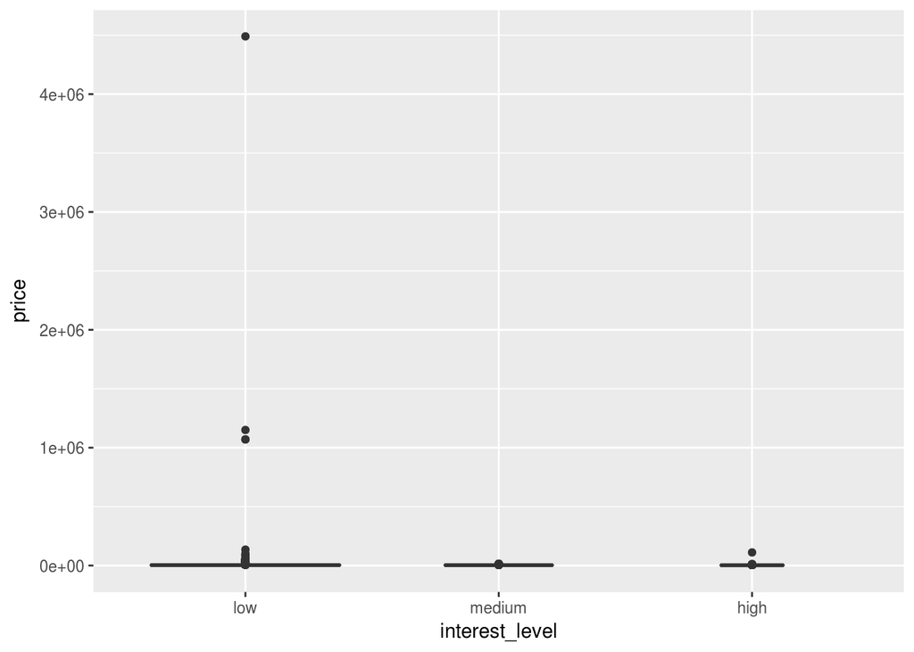

```r
price_box <- listings %>%
  filter(section == 'train')

ggplot(price_box, aes(interest_level, price)) + geom_boxplot(varwidth = TRUE)
```

As expected a few extreme outliers distort the results. We need to limit the y axis range in ggplot2.

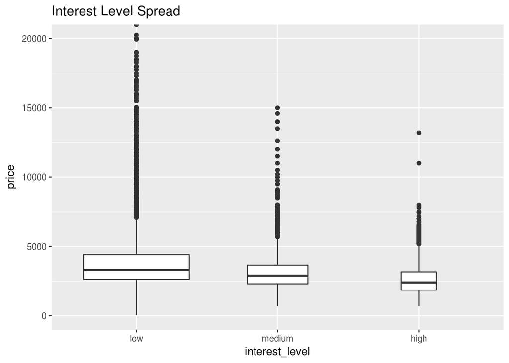

```r
ggplot(price_box, aes(interest_level, price)) + geom_boxplot(varwidth = TRUE) + coord_cartesian(ylim = c(0, 20000)) + ggtitle("Interest Level Spread")
```

We can see the those listings with low interest are higher in general, but also have a large number of expensive outliers, which are also reasonable for NYC. The high interest listings have a lower median price, and a narrower distribution.

### Density Plot

Let’s look at price distribution with a density plot.

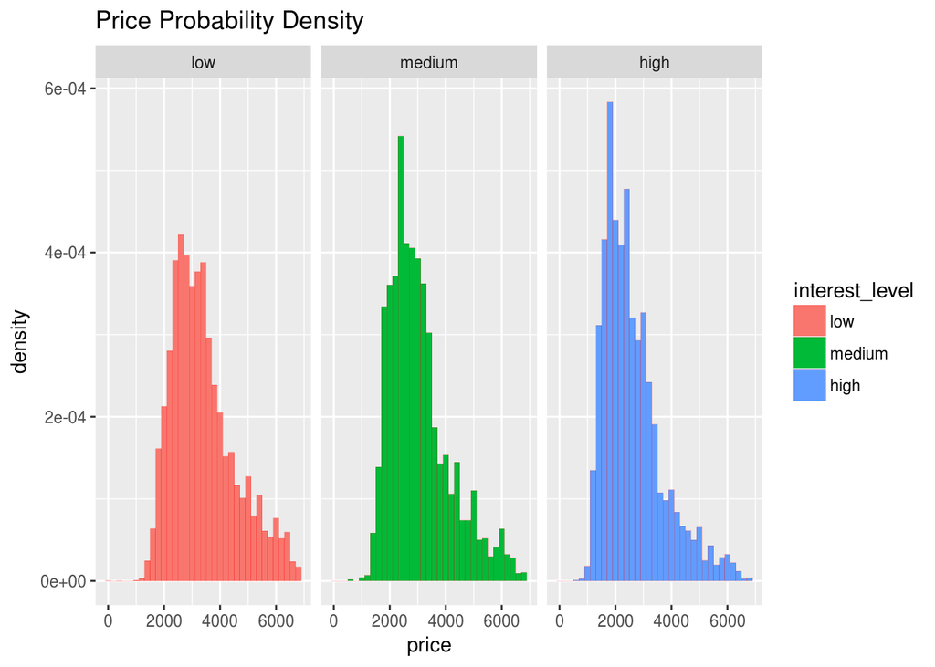

```r
#Price density plot
listings %>% filter(price <= quantile(listings$price, 0.95), section == 'train') %>%
ggplot(aes(x = price, fill = interest_level)) +
    geom_histogram(aes(y = ..density..), binwidth= 200, position = "identity", color = "red", size = .04) +
    facet_grid(.~interest_level) +
    ggtitle("Price Probability Density")
```

We can see from this plot that the listings with higher interest are much more concentrated around low price. Also, like a lot of transaction data it is not normal. It’s clearly skewed to the right. This happens because on the lower side the price distribution is bound by zero, yet there is a lot of room to ask for high prices. No one would pay you to live in their apartment.

### Proportion of Bedroom in Interest Level

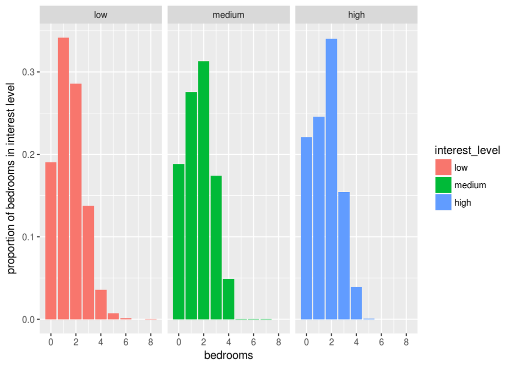

```r
#summary table for bar chart
filter(listings, section == 'train') %>%
group_by(bedrooms, interest_level) %>%
  summarize(room_count = n()) %>%
  ungroup() %>%
  group_by(interest_level) %>%
  mutate(total_bedrooms = sum(room_count)) %>%
  mutate(p = room_count/total_bedrooms) %>%
  ggplot(aes(bedrooms, p)) +
  geom_bar(aes(fill = interest_level), stat = "identity")  +
  facet_grid(.~interest_level) +
  ylab("proportion of bedrooms in interest level")
```

### Prices by Number of Bedrooms

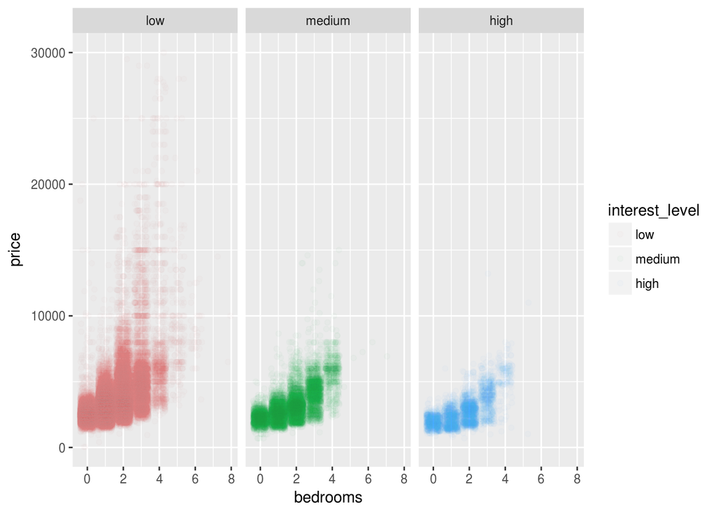

```r
filter(listings, price <= quantile(listings$price, 0.999), section == 'train') %>%
ggplot(aes(x = bedrooms, y = price)) +
  geom_jitter(aes(color = interest_level), alpha = 0.02) +
  facet_grid(.~interest_level)
```

The price of apartments with bedmore rooms increases. It increases faster for low interest apartments. Interest in an apartment decreases quickly after the price gets to about $8,000 per month.

### Price to Room Ratio

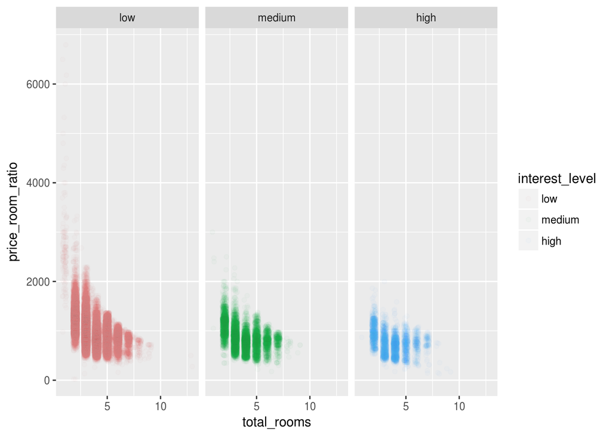

```r
filter(listings, price <= quantile(listings$price, 0.95), section == 'train') %>%
ggplot(aes(x = total_rooms, y = price_room_ratio)) +
  geom_jitter(aes(color = interest_level), alpha = 0.02) +
  facet_grid(.~interest_level)
```

### Feature Count Density

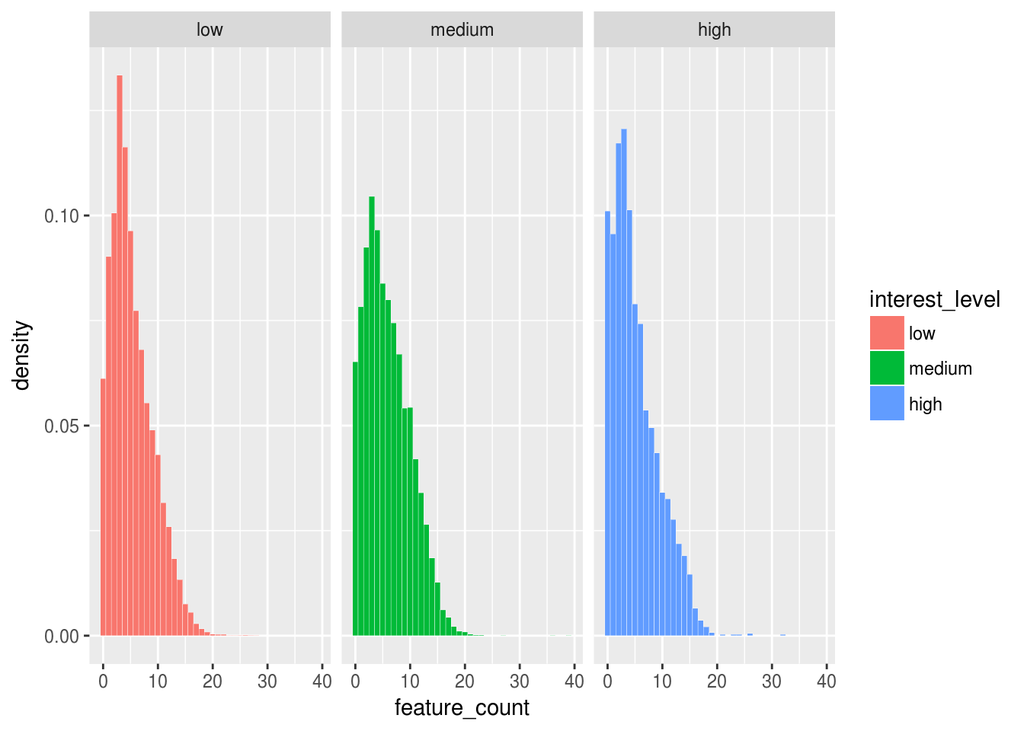

```r
#features by interest
filter(listings, price <= quantile(listings$price, 1.00), section == 'train') %>%
ggplot(aes(x = feature_count)) +
  geom_histogram(aes(y = ..density.., fill = interest_level),
                 bins = 40, position = "identity", color = "white", size = 0.07) +
  facet_grid(.~interest_level) +
  guides(color = FALSE)
```

The density of feature count doesn’t seem to vary greatly by interest level. Most listings have about 5 features.

### Price by Number of Features

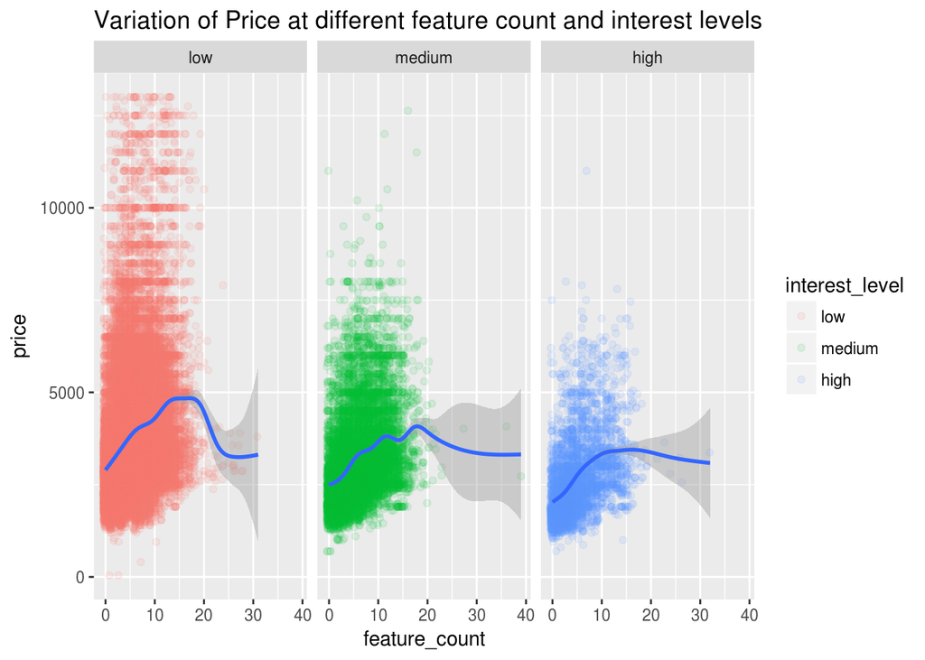

```r
#price by number of features
filter(listings, price <= quantile(listings$price, 0.99), section == 'train') %>%
ggplot(aes(x = feature_count, y = price)) +
  geom_jitter(aes(color = interest_level), alpha = .10) +
  facet_grid(.~interest_level) +
  ggtitle("Variation of Price at different feature count and interest levels") +
geom_smooth()
```

Excluding outliers there is a clear positive relationship between feature_count and price. If you want more money then you need to explain why your apartment is worth it. There are also many high priced apartments with a low interest level and a small number of features listed. That makes sense. Work harder:)

### Photo Count Density

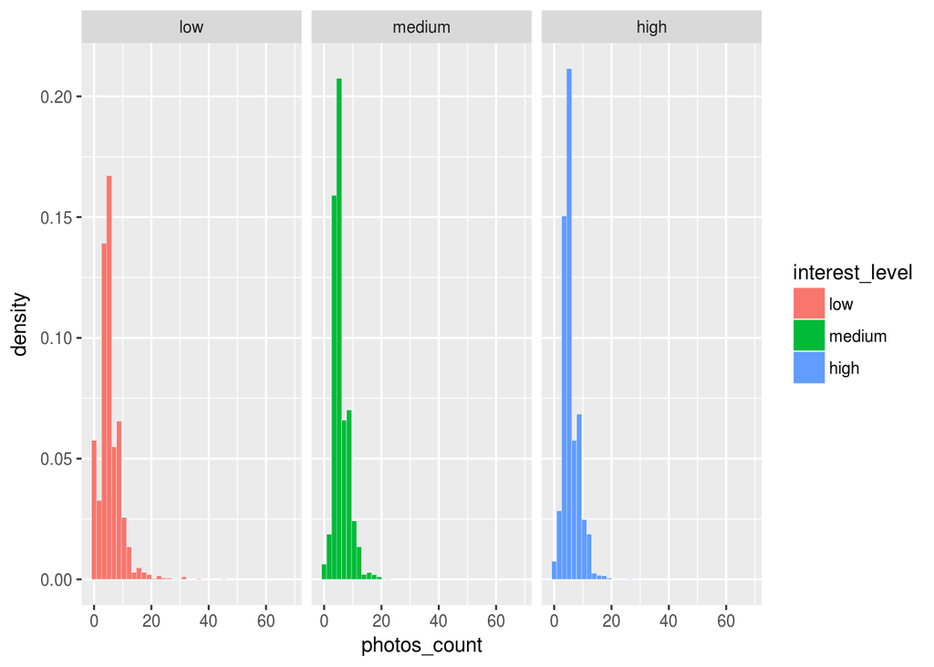

```r
#photos by interest
filter(listings, price <= quantile(listings$price, 1.00), section == 'train') %>%
ggplot(aes(x = photos_count)) +
  geom_histogram(aes(y = ..density.., fill = interest_level),
                 bins = 40, position = "identity", color = "white", size = 0.07) +
  facet_grid(.~interest_level) +
  guides(color = FALSE)
```

The density of photo count doesn’t seem to vary greatly by interest level. Most listings have about 5 photos

### Price by Number of Photos

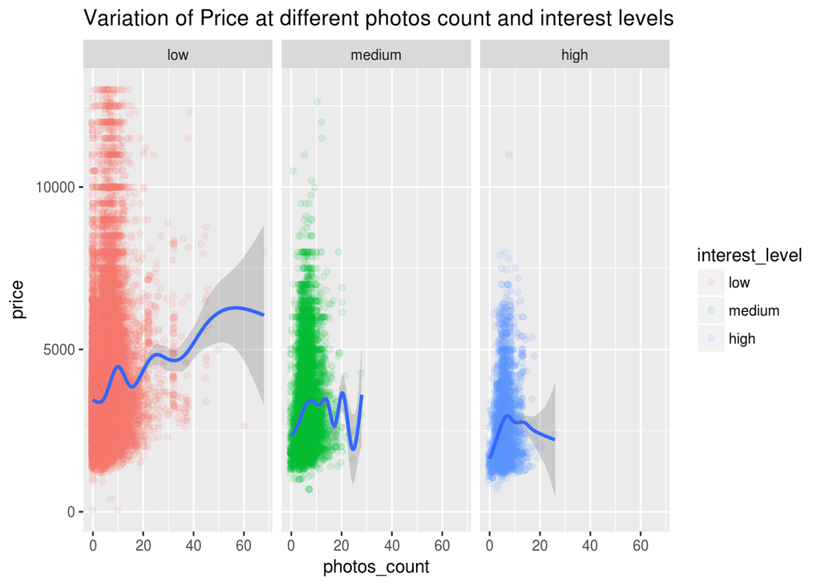

```r
#price by number of photos
filter(listings, price <= quantile(listings$price, 0.99), section == 'train') %>%
ggplot(aes(x = photos_count, y = price)) +
  geom_jitter(aes(color = interest_level), alpha = .10) +
  facet_grid(.~interest_level) +
  ggtitle("Variation of Price at different photos count and interest levels") +
geom_smooth()
```

### Listings Creation Date

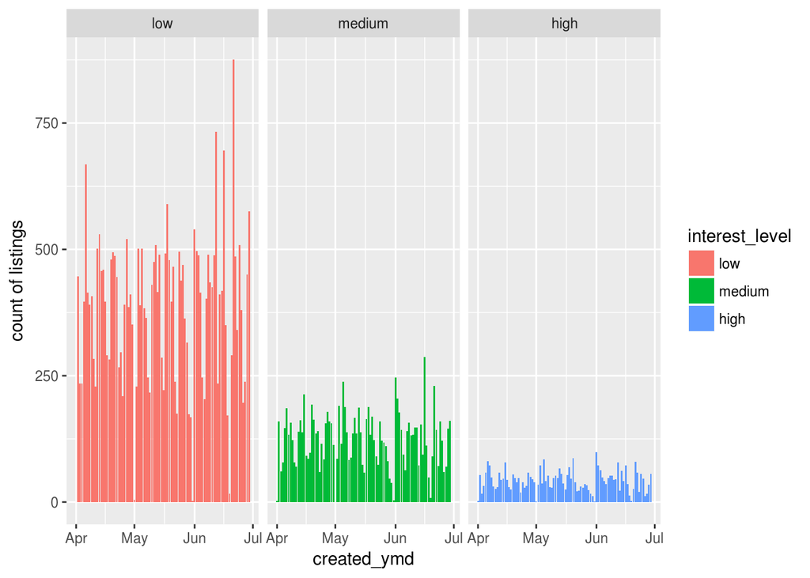

```r
listings %>% filter(section == 'train') %>%
ggplot(mapping = aes(created_ymd)) +
  geom_bar(aes(fill = interest_level)) +
  facet_grid(~interest_level) +
  ylab("count of listings")
```

```r
dates_train <- listings %>% filter(section == 'train') %>%
  select(created_ymd) %>%
  unique() %>%
  arrange(created_ymd)

dates_test <- listings %>% filter(section == 'test') %>%
  select(created_ymd) %>%
  unique() %>%
  arrange(created_ymd)

identical(dates_train,dates_test)
```

```
## [1] TRUE
```

The date range of the training and testing data are exactly the same. It would be nice to have an out of time sample to test models on. Testing them on a test set from the same time span may lead to overoptimistic results. Maybe Renthop had reasons for this.

The timeframe of the data is from April 1st to June 29th. There doesn’t seem to be a long term trend, but there might be some weekly or hourly trends. Let’s look and find out.

### Listing DOW Trend

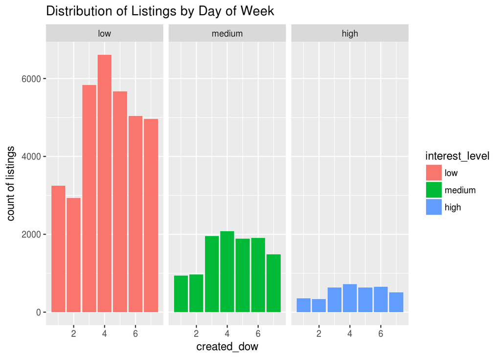

```r
listings %>% filter(section == 'train') %>%
ggplot(mapping = aes(created_dow)) +
  geom_bar(aes(fill = interest_level)) +
  facet_grid(~interest_level) +
  ylab("count of listings") +
  ggtitle("Distribution of Listings by Day of Week")
```

Sunday is the first day of the week. We can see thos most listings are entered on Wednesday. This is the middle of the workweek for agents.

### Listing Hourly Trend

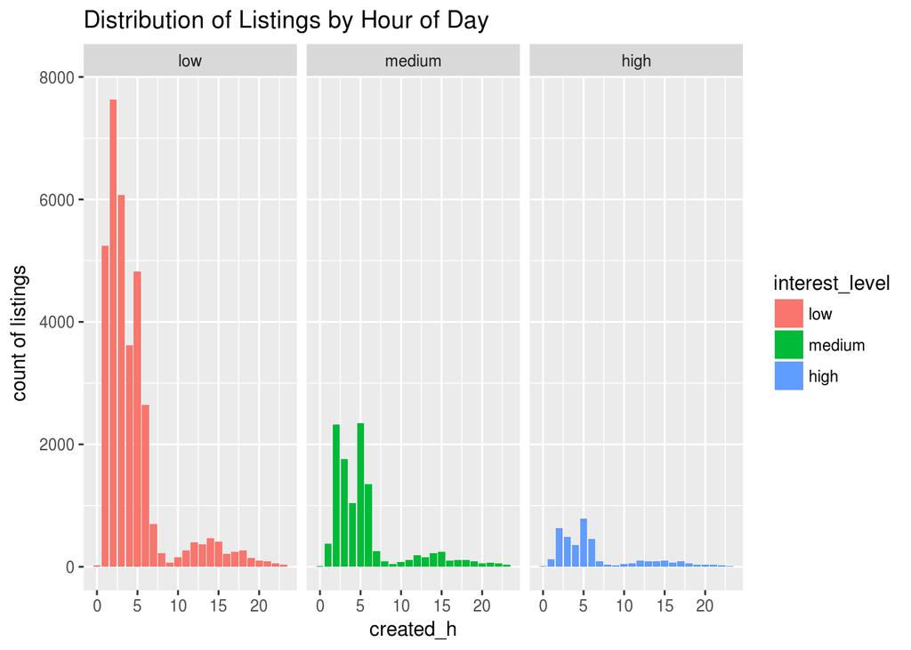

```r
listings %>% filter(section == 'train') %>%
ggplot(mapping = aes(created_h)) +
  geom_bar(aes(fill = interest_level)) +
  facet_grid(~interest_level) +
  ylab("count of listings") +
  ggtitle("Distribution of Listings by Hour of Day")
```

Most listings were created between midnight and 6:00 in the morning. Since most people sleep at that time, there must be a timezone issue.

```r
tz(listings$created)
```

```
## [1] "UTC"
```

So, this data appears to be set to UTC, yet since it’s just a character and not set to any sort of date time object, I would guess that UTC is just the default for the tz function. We know this is for NYC, and most of the listings were probably created by people in NYC. This being the case something funny is going on. I don’t believe most people would create a listing so early in the morning.

### View Spatial Distribution

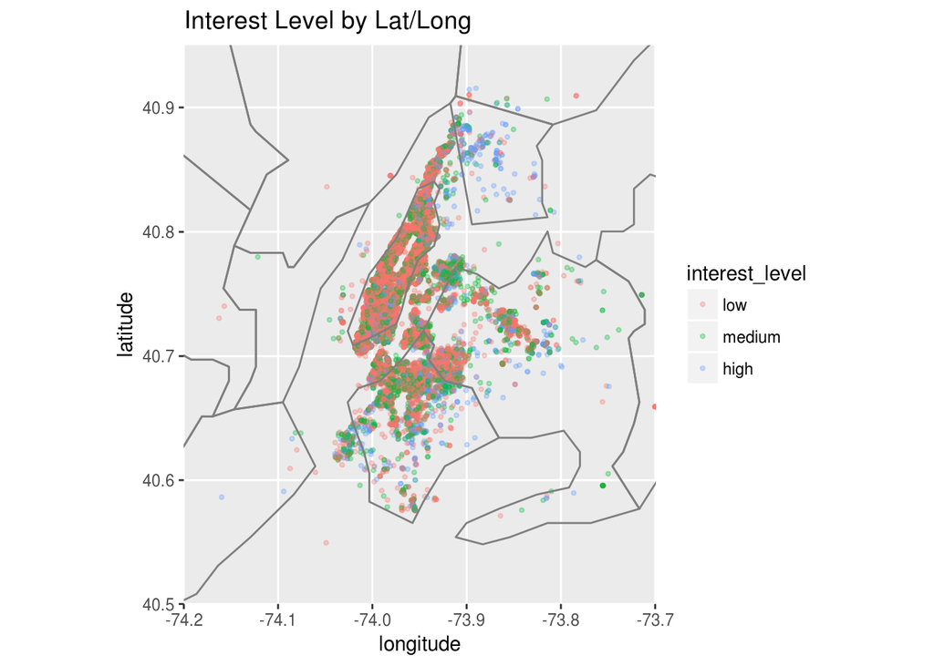

```r
listings %>% filter(section == 'train') %>%
ggplot(aes(x=longitude, y=latitude)) +
geom_point(aes(color = interest_level), size = 0.8, alpha = 0.3) +
borders("county") +
coord_map(xlim = c(-74.20, -73.70), ylim = c(40.50, 40.95)) +
ggtitle("Interest Level by Lat/Long")
```

Initial indications show that the outlying areas (outside of Manhattan) have a higher occurence of high interest listings. They are probably cheaper. Let’s take a closer look at Manhattan to see if we can see anything that may be obscurred at a distance.

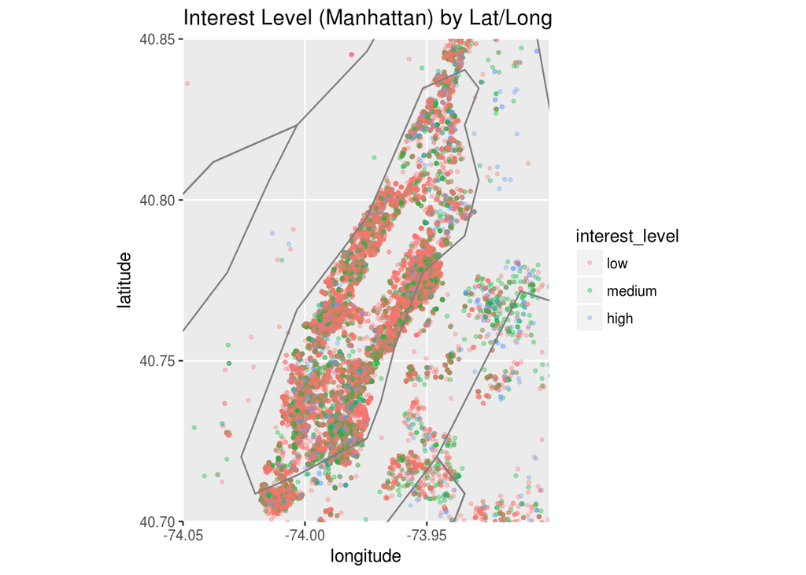

```r
listings %>% filter(section == 'train') %>%
ggplot(aes(x=longitude, y=latitude)) +
geom_point(aes(color = interest_level), size = 0.8, alpha = 0.3) +
borders("county") +
coord_map(xlim = c(-74.05, -73.9 ), ylim = c(40.70, 40.85)) +
ggtitle("Interest Level (Manhattan) by Lat/Long")
```

### Popular Property Managers

It could be that certain property managers are very popular. If so, the property manager ID could be an important feature.

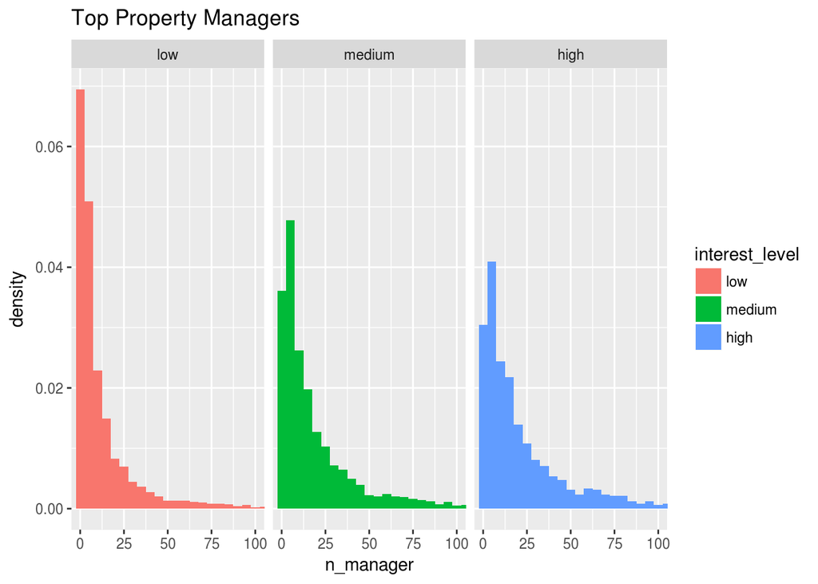

```r
manager_count <- listings %>% filter(section == 'train') %>%
  group_by(manager_id) %>%
  summarise(n_manager = n()) %>%
  arrange(manager_id)

manager_interest_count <- listings %>% filter(section == 'train') %>%
  group_by(manager_id, interest_level) %>%
  summarise(n_manager_interest = n()) %>%
  arrange(manager_id)

inner_join(manager_count, manager_interest_count) %>%
  mutate(interest_pct = n_manager_interest / n_manager) %>%
  ggplot(aes(x = n_manager)) +
  geom_histogram(aes(y = ..density.., fill = interest_level), binwidth = 5) +
  facet_grid(.~interest_level) +
  coord_cartesian(xlim=c(0, 100)) +
  ggtitle("Top Property Managers")
```

Therer are many managers with 0 to 10 listings. Let’s filter on those with more than 10, and consider those potential popular managers.

```r
(manager_interest_pct <- inner_join(manager_count, manager_interest_count) %>%
  mutate(interest_pct = n_manager_interest / n_manager) %>%
  filter(interest_level == "high", n_manager >= 10, interest_pct > 0.5) %>%
  arrange(-interest_pct))
```

```
## # A tibble: 12 × 5
##                          manager_id n_manager interest_level
##                               <chr>     <int>         <fctr>
## 1  603575a3da76fa757cd6451f3707819d        26           high
## 2  456848d13f96dc522e5cf381095caeca        31           high
## 3  f948a6d058c0d51c2b802734f5db9d74        11           high
## 4  35f11f952ba96803a9d9e23e83e7f972        46           high
## 5  c80aad40b6abd065b4aefee40a2154f6        15           high
## 6  e9920062e07ee893c10e38d0259665b0        27           high
## 7  2529098e553450cef6ba3198a1c2eec4        12           high
## 8  cb91d4992adf2a996e1454fb39434fb8        12           high
## 9  12c0a30e296faa0dfd422fe918d7d4f4        91           high
## 10 3b630ec9cb6eee53b92cfac7f42e3bf4        29           high
## 11 53072af31d51fcdbc29dba6bc28a5011        15           high
## 12 3e04672678ee02c7bb843a9d4641c440        17           high
## # ... with 2 more variables: n_manager_interest <int>, interest_pct <dbl>
```

There are 12 property managers who have at least 10 listings at least 50% of which have a high interest level. These managers have done something right. A feature should be created which calls them out.

### Popular buildings

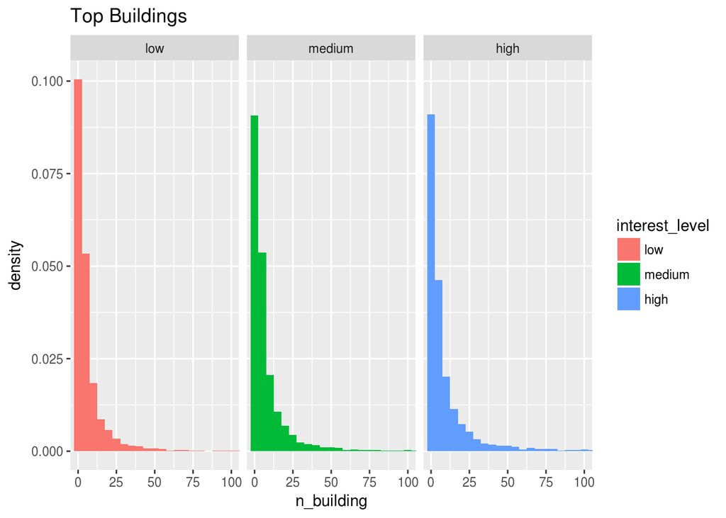

```r
building_count <- listings %>% filter(section == 'train') %>%
  group_by(building_id) %>%
  summarise(n_building = n()) %>%
  arrange(building_id)

building_interest_count <- listings %>% filter(section == 'train') %>%
  group_by(building_id, interest_level) %>%
  summarise(n_building_interest = n()) %>%
  arrange(building_id)

inner_join(building_count, building_interest_count) %>%
  mutate(interest_pct = n_building_interest / n_building) %>%
  ggplot(aes(x = n_building)) +
  geom_histogram(aes(y = ..density.., fill = interest_level), binwidth = 5) +
  facet_grid(.~interest_level) +
  coord_cartesian(xlim=c(0, 100)) +
  ggtitle("Top Buildings")
```

After about 10 listings the numbers decrease. Let’s look at those building with at least 10 listings and a high interest level above 50%.

```r
(building_interest_pct <- inner_join(building_count, building_interest_count) %>%
  mutate(interest_pct = n_building_interest / n_building) %>%
  filter(interest_level == "high", n_building >= 10, interest_pct > 0.5) %>%
  arrange(-interest_pct))
```

```
## # A tibble: 9 × 5
##                        building_id n_building interest_level
##                              <chr>      <int>         <fctr>
## 1 fe1a54852575e1c8537c21ed307e68cf         19           high
## 2 93311e4f21f4538715a50e2148cdc8d7         14           high
## 3 d98c8b56ed3e53e3342c069256d9ef89         10           high
## 4 8476f31a8ec5e73a903423ac84ab8b14         13           high
## 5 6328b99187772613afdd9b249a587805         26           high
## 6 35dd428957bcaaf91495d78d438a342b         14           high
## 7 71c3dd94524c65a0bbb90e582e5f81f0         11           high
## 8 0de97434d3c89fde23d42429f5867ae0         21           high
## 9 f39ceb086e28db31a94e22a3a1c687cd         23           high
## # ... with 2 more variables: n_building_interest <int>, interest_pct <dbl>
```

Just 9 buildings made the cut. Let’s see where they are.

```r
building_map_data <- inner_join(building_interest_pct, listings)
```

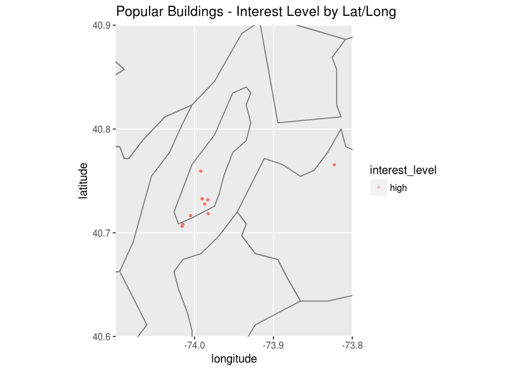

```r
building_map_data %>%
ggplot(aes(x=longitude, y=latitude)) +
geom_point(aes(color = interest_level), size = 0.8, alpha = 0.3) +
borders("county") +
coord_map(xlim = c(-74.10, -73.80), ylim = c(40.60, 40.90)) +
ggtitle("Popular Buildings - Interest Level by Lat/Long")
```

Most of the popular buildings are in lower Manhattan. A feature could be created which specifies the distance of a given building from this area.

### Most Common Listed Features

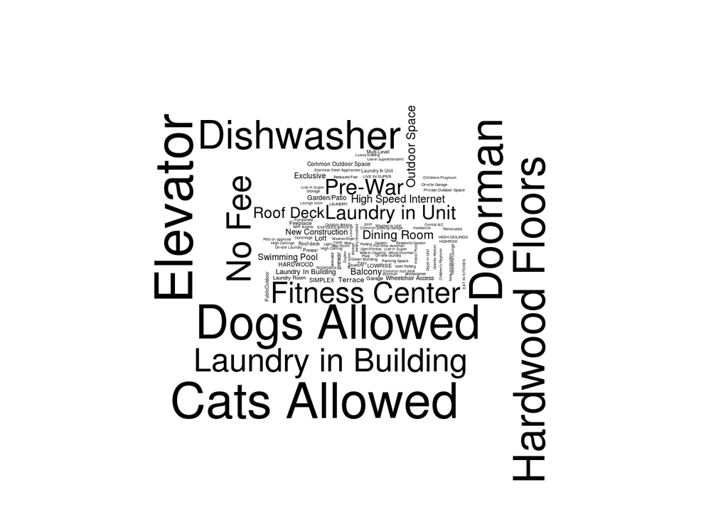

```r
features_low <- data %>% filter(interest_level == "low") %>%
  select(features) %>%
  unlist() %>%
  as_tibble() %>%
  group_by(value) %>%
  summarize(feature_count = n()) %>%
  arrange(desc(feature_count))

wordcloud(features_low$value, features_low$feature_count, scale=c(3,.2), min.freq = 30)
```

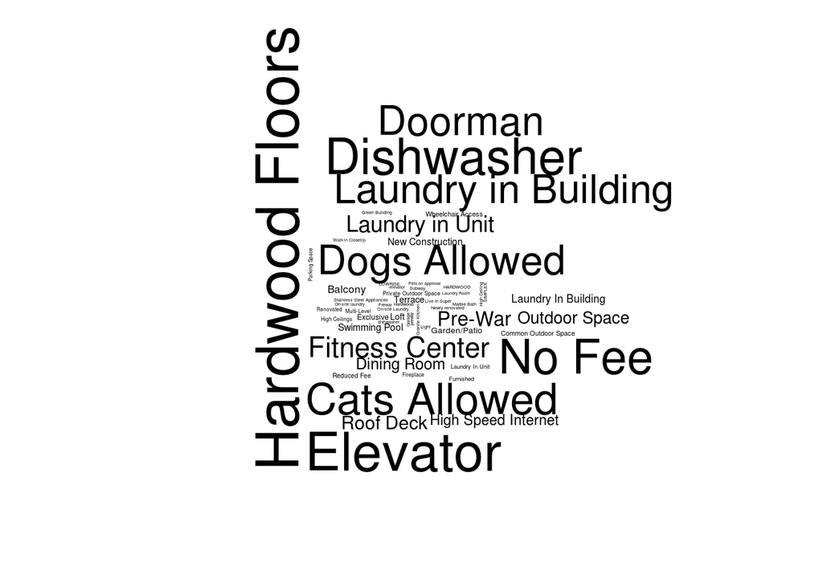

```r
features_medium <- data %>% filter(interest_level == "medium") %>%
  select(features) %>%
  unlist() %>%
  as_tibble() %>%
  group_by(value) %>%
  summarize(feature_count = n()) %>%
  arrange(desc(feature_count))

wordcloud(features_medium$value, features_medium$feature_count, scale=c(3,.2), min.freq = 30)
```

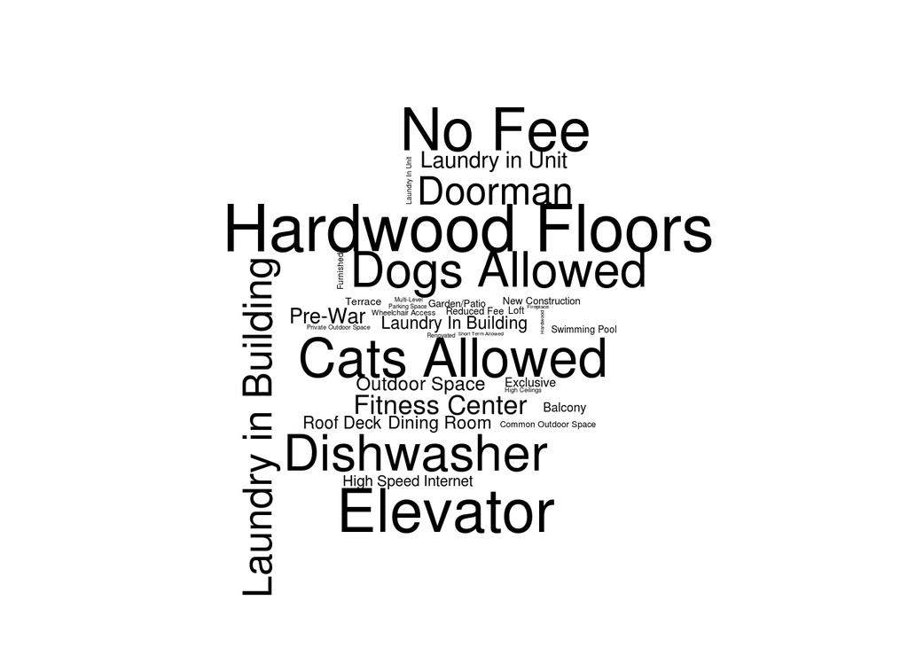

```r
features_high <- data %>% filter(interest_level == "high") %>%
  select(features) %>%
  unlist() %>%
  as_tibble() %>%
  group_by(value) %>%
  summarize(feature_count = n()) %>%
  arrange(desc(feature_count))

wordcloud(features_high$value, features_high$feature_count, scale=c(3,.2), min.freq = 30)
```

The resutls all seem fairly similar. Hardwood floors are popular. So are pets. “Doorman” isn’t mentioned as much in the high interest listings. That probably has a relationship to price.

### Find and replace obviously invalid outliers

There were a lot of outliers for price. Although, they were much higher than most, many of them were still possible given that most of the listings were in Manhattan. The high prices will effectively be taken care of later by log transforms. There may be other outliers, which simply can’t be true. Let’s look for them and replace them with reasonable values.

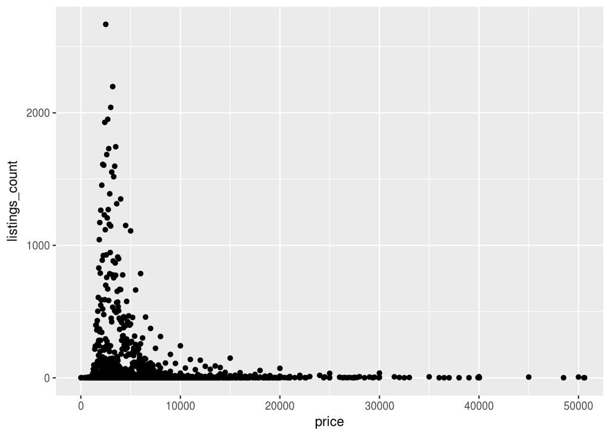

```r
listings %>%
  group_by(price) %>%
  summarize(listings_count = n()) %>%
  ggplot(aes(price, listings_count)) +
  geom_point() +
  coord_cartesian(xlim = c(0, 50000))
```

Nothing obvious stands out on price. I wouldn’t pay some of these prices, but there may be some people.

What about Latitude and longitude? This is supposed to be for NYC. We know from the “View Spatial Distribution” section that the longitude and latitude should be approximately within this box; longitude = c(-74.20, -73.70), latitude = c(40.50, 40.95). So, anything outside this box doesn’t make sense.

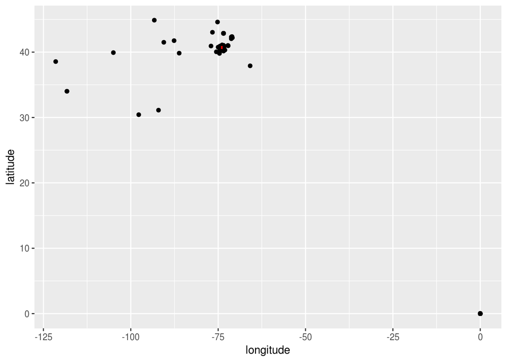

```r
unlikely_geo <- listings %>% filter(longitude < -74.20 | longitude > -73.70 | latitude < 40.50 | latitude > 40.95)

ggplot(unlikely_geo, aes(longitude, latitude)) +
  geom_point() +
  geom_rect(xmin = -74.20 , xmax = -73.70,   ymin = 40.50, ymax = 40.95,   fill = "red")
```

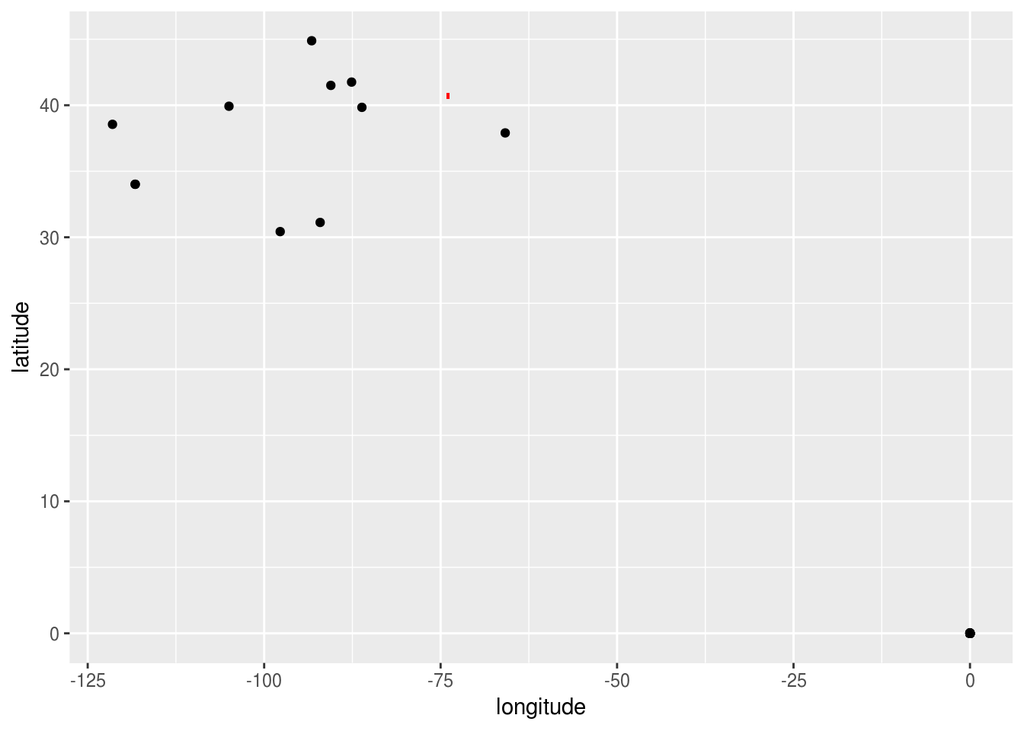

```r
long_range <- abs(abs(-74.20) - abs(-73.70))
lat_range <- abs(abs(40.50) - abs(40.95))

very_unlikely_geo <- listings %>% filter(longitude < -74.20 - (10 * long_range) | longitude > -73.70 + (10 * long_range) | latitude < 40.50 - (10 * lat_range) | latitude > 40.95 + (10 * lat_range))

ggplot(very_unlikely_geo, aes(longitude, latitude)) +
  geom_point() +
  geom_rect(xmin = -74.20 , xmax = -73.70,   ymin = 40.50, ymax = 40.95,   fill = "red")
```

The black points above are for the 52 listings with unreasonable coordinates. Their latitude and longitude values will be changed to the median respectively.

```r
lat_median <- median(listings$latitude)
long_median <- median(listings$longitude)

listings %>% filter(listing_id %in% very_unlikely_geo$listing_id) %>%
  mutate(latitude = lat_median,
         longitude = long_median)
```

```
## # A tibble: 52 × 26
##    bathrooms bedrooms                      building_id             created
##        <dbl>    <dbl>                            <chr>               <chr>
## 1          1        1 1490317c3a31185f0c8115f01d1acc5b 2016-05-31 22:26:06
## 2          1        1                                0 2016-06-01 19:59:46
## 3          1        2 a1b2bd0758c6f14be815e4d9382b8169 2016-06-16 15:38:11
## 4          1        1 117aceb94c48bfd1f3066a22f999705f 2016-06-17 02:10:25
## 5          1        2 8f837ada8d7ec5d251a369cd5909af7c 2016-05-07 08:15:32
## 6          1        2 ebb1fe8e32b8565f057a20abc495a2b5 2016-05-10 10:25:19
## 7          4        3 f389c8eb16e5d0c771615fb30f3cc9d6 2016-05-11 18:07:15
## 8          1        1 4d7c804afea366c666731bee9c56919e 2016-05-10 14:30:12
## 9          1        2 55ab81a4ccd5ea862fba344dc29f1463 2016-05-24 17:43:39
## 10         1        1 09e6efa1a58a3cd753aeee80bdf5ec36 2016-05-10 10:11:20
## # ... with 42 more rows, and 22 more variables: description <chr>,
## #   display_address <chr>, latitude <dbl>, listing_id <dbl>,
## #   longitude <dbl>, manager_id <chr>, price <dbl>, street_address <chr>,
## #   interest_level <fctr>, section <chr>, photos_count <int>,
## #   feature_count <int>, dates_formatted <dttm>, total_rooms <dbl>,
## #   beds_bath_ratio <dbl>, price_room_ratio <dbl>, price_bath_ratio <dbl>,
## #   price_photos_ratio <dbl>, price_feature_ratio <dbl>,
## #   created_ymd <date>, created_dow <dbl>, created_h <int>
```

Save the “listings” object for use in the next section.

```r
saveRDS(listings, file = "../data/objects/listings.rds")
```